# Caso de Estudio DYCD

Jorge Eduardo Gomez Forero

17/02/2021

## 1. Descripción del Estudio

El Banco DYCD desea segmentar las variables que le permitan entender y facilitar la toma de decisiones, frente a la segmentación de fuga de clientes.

Para el desarrollo de este estudio, la compañia suministra la bases de datos:

*Base prueba DCYD.xlsx: 521 registros de los clientes que presentaron deserción con 67 campos discriminados entre variables sociodemograficas, endeudamiento, salario entre otras.*

```r
library(readxl) #Leer archivo de Excel
library(rpart)  #Libreria para generar arból de decisión
library(rpart.plot)  #grágica del arbol de decisión
library(dplyr) #Operador %>%
library(ggplot2) #Gráficas
library(caret) # función matriz de confución (confusionMatrix)
```

## 2. Recategorización, creación y exclusión de la información:

• Descripción del proceso de recategorización (datos faltantes a NS/NR, unificación de categorías, transformaciones de variables entre otras).

En terminos generales la base de datos presenta información organizada, solo se ajustaron 3 variables y se crearon 2 a partir de la informaciòn proporcionada en la base.

| Variable | Recategorización |
| --- | --- |
| ComportamientoExterno | 1= Presenta comportamiento, 0= No presenta comportamiento |
| CondicionDesercion | 1 = Presenta deserción |
| TieneAlivio | 1 = Tiene Alivio, 0 = Celdas vacías |
| Deuda Finandina Vs Ingreso | Proporción de la deuda sobre el ingreso |
| Ultimo Saldo Vs Ingreso | Proporción del último saldo sobre el ingreso |

• Dado un estudio premiliminar que se habia realizado con un reporte de python (archivos 21_DeserTotFinandina.html, 22_DeserVehFinandina.html, 23_DeserLInvFinandina.html), se observa que la base contiene variables que no le aportan al estudio estadístico, teniendo en cuenta que presentan la misma categoria o valor, corresponden a datos sencibles del cliente o solo presentan 1 marca diferente, dichas variables son:

- NumeroTelefono1
- NumeroTelefono2
- NumeroTelefono3
- Celular1
- Celular2
- Direccion1
- Email1
- Email2
- SaldoCapital
- VrGarantiaActual
- TasaTarjeta
- TasaAutoEfectivo
- TasaVehiculos
- P_Edad
- AciertaA_Ins
- AciertaA_TDC
- Cierre
- CondicionDesercion
- FechaUltimoMovimiento
- ComportamientoExterno

Data summary

| Name | df_desercion2 |
| --- | --- |
| Number of rows | 521 |
| Number of columns | 48 |
| _______________________ |  |
| Column type frequency: |  |
| character | 8 |
| numeric | 40 |
| ________________________ |  |
| Group variables | None |

**Variable type: character**

| skim_variable | n_missing | complete_rate | min | max | empty | n_unique | whitespace |
| --- | --- | --- | --- | --- | --- | --- | --- |
| CIUDAD | 0 | 1.00 | 4 | 20 | 0 | 74 | 0 |
| Genero | 79 | 0.85 | 1 | 1 | 0 | 2 | 0 |
| RangoEdad | 0 | 1.00 | 3 | 5 | 0 | 6 | 0 |
| Rta_Estrategia | 0 | 1.00 | 9 | 12 | 0 | 2 | 0 |
| Riesgo | 0 | 1.00 | 1 | 2 | 0 | 8 | 0 |
| RangoEdad2 | 0 | 1.00 | 3 | 5 | 0 | 6 | 0 |
| Clasificacion | 0 | 1.00 | 7 | 9 | 0 | 2 | 0 |
| Producto | 0 | 1.00 | 8 | 15 | 0 | 3 | 0 |

**Variable type: numeric**

| skim_variable | n_missing | complete_rate | mean | sd | p0 | p25 | p50 | p75 | p100 | hist |
| --- | --- | --- | --- | --- | --- | --- | --- | --- | --- | --- |
| NumeroIdentificacion | 0 | 1 | 271.00 | 150.54 | 11 | 141.00 | 271.00 | 401.00 | 5.310000e+02 | ▇▇▇▇▇ |
| Ingresos | 0 | 1 | 8647119.00 | 8606098.40 | 877000 | 3440000.00 | 5907000.00 | 10700000.00 | 1.141310e+08 | ▇▁▁▁▁ |
| TarjetaCredito | 0 | 1 | 6822453.45 | 5951084.60 | 0 | 2449000.00 | 5565000.00 | 10000000.00 | 2.000000e+07 | ▇▃▃▂▂ |
| TarjetaCredito_ESP | 0 | 1 | 8654166.03 | 10471785.09 | 0 | 2449000.00 | 5565000.00 | 10000000.00 | 5.000000e+07 | ▇▂▁▁▁ |
| Veh_36M | 0 | 1 | 42019577.74 | 32973938.44 | 0 | 19700000.00 | 32500000.00 | 65700000.00 | 1.000000e+08 | ▇▇▃▂▅ |
| Veh_48M | 0 | 1 | 47692706.33 | 34936968.86 | 0 | 20000000.00 | 39600000.00 | 80100000.00 | 1.000000e+08 | ▇▇▅▃▇ |
| Veh_60M | 0 | 1 | 51589827.26 | 35958036.87 | 0 | 22900000.00 | 45400000.00 | 91900000.00 | 1.000000e+08 | ▆▆▃▃▇ |
| Veh_TDC | 0 | 1 | 6666755.76 | 5694252.26 | 0 | 2400000.00 | 5496250.00 | 10000000.00 | 2.000000e+07 | ▇▃▃▂▂ |
| AutoEfectivo36M | 0 | 1 | 23158349.33 | 20389932.76 | 0 | 12900000.00 | 16700000.00 | 30000000.00 | 7.000000e+07 | ▅▇▃▁▂ |
| AutoEfectivo48M | 0 | 1 | 23933013.44 | 21374635.95 | 0 | 13000000.00 | 17200000.00 | 30000000.00 | 7.000000e+07 | ▅▇▃▁▃ |
| AutoEfectivo60M | 0 | 1 | 23948560.46 | 21400376.59 | 0 | 13000000.00 | 17200000.00 | 30000000.00 | 7.000000e+07 | ▅▇▃▁▃ |
| AutoEfectivoTDC | 0 | 1 | 4488398.75 | 4019900.64 | 0 | 2400000.00 | 3000000.00 | 6000000.00 | 1.400000e+07 | ▆▇▃▁▂ |
| P_CapacidadPago | 0 | 1 | 0.15 | 0.36 | 0 | 0.00 | 0.00 | 0.00 | 1.000000e+00 | ▇▁▁▁▂ |
| P_Mor30_24M | 0 | 1 | 0.02 | 0.15 | 0 | 0.00 | 0.00 | 0.00 | 1.000000e+00 | ▇▁▁▁▁ |
| P_Mor90_12M | 0 | 1 | 0.01 | 0.12 | 0 | 0.00 | 0.00 | 0.00 | 1.000000e+00 | ▇▁▁▁▁ |
| P_Embargos | 0 | 1 | 0.02 | 0.13 | 0 | 0.00 | 0.00 | 0.00 | 1.000000e+00 | ▇▁▁▁▁ |
| P_Recup | 0 | 1 | 0.03 | 0.16 | 0 | 0.00 | 0.00 | 0.00 | 1.000000e+00 | ▇▁▁▁▁ |
| P_CalificacionMRCoBCDE | 0 | 1 | 0.07 | 0.26 | 0 | 0.00 | 0.00 | 0.00 | 1.000000e+00 | ▇▁▁▁▁ |
| P_Castigos | 0 | 1 | 0.01 | 0.08 | 0 | 0.00 | 0.00 | 0.00 | 1.000000e+00 | ▇▁▁▁▁ |
| P_Score | 0 | 1 | 0.20 | 0.40 | 0 | 0.00 | 0.00 | 0.00 | 1.000000e+00 | ▇▁▁▁▂ |
| Politica_Ingresos | 0 | 1 | 0.00 | 0.04 | 0 | 0.00 | 0.00 | 0.00 | 1.000000e+00 | ▇▁▁▁▁ |
| TotalPoliticasIncumplidas | 0 | 1 | 0.52 | 1.06 | 0 | 0.00 | 0.00 | 0.00 | 6.000000e+00 | ▇▁▁▁▁ |
| AciertaA_GN | 0 | 1 | 798.73 | 107.73 | 424 | 736.00 | 825.00 | 883.00 | 9.690000e+02 | ▁▂▅▇▇ |
| Acierta_Master | 0 | 1 | 798.73 | 107.73 | 424 | 736.00 | 825.00 | 883.00 | 9.690000e+02 | ▁▂▅▇▇ |
| DF_Portafolio | 0 | 1 | 2165441.76 | 2733964.91 | -2441745 | 794250.00 | 1448250.00 | 3052500.00 | 2.853275e+07 | ▇▂▁▁▁ |
| DF_Producto | 0 | 1 | 1827802.03 | 2354481.61 | -2441745 | 737250.00 | 1292500.00 | 2554250.00 | 2.853275e+07 | ▇▁▁▁▁ |
| CuotaReal | 0 | 1 | 4890828.52 | 10945067.86 | 0 | 1351816.62 | 2668521.12 | 4705024.08 | 2.063803e+08 | ▇▁▁▁▁ |
| CuotaPotencial | 0 | 1 | 6277959.44 | 11430035.27 | 0 | 1896054.48 | 3511212.00 | 6706414.92 | 2.065734e+08 | ▇▁▁▁▁ |
| Deuda.financiera | 0 | 1 | 132595224.57 | 212874411.04 | 0 | 12602000.00 | 57082000.00 | 170502000.00 | 2.133829e+09 | ▇▁▁▁▁ |
| Deuda.hipotecaria | 0 | 1 | 76659353.17 | 158049642.47 | 0 | 5176000.00 | 27837000.00 | 86918000.00 | 2.133829e+09 | ▇▁▁▁▁ |
| Deuda.financiera.con.Finandina | 0 | 1 | 33704422.26 | 28792283.12 | 0 | 12787000.00 | 25028000.00 | 45468000.00 | 1.587600e+08 | ▇▃▂▁▁ |
| Deuda.financiera.TodasObligFinanc | 0 | 1 | 158255243.76 | 213478815.74 | 0 | 40387000.00 | 85831000.00 | 199862000.00 | 2.283421e+09 | ▇▁▁▁▁ |
| Deuda.financiera.sin.Hipotecaria | 0 | 1 | 103207696.74 | 156973292.71 | 0 | 29155000.00 | 58008000.00 | 118749000.00 | 2.283421e+09 | ▇▁▁▁▁ |
| Maximo.cupo.TDC | 0 | 1 | 14756168.91 | 17321502.06 | 0 | 4400000.00 | 10000000.00 | 19500000.00 | 1.930000e+08 | ▇▁▁▁▁ |
| TotalCreditoHipotecario | 0 | 1 | 26548343.57 | 46901133.62 | -653817000 | 3162000.00 | 20562000.00 | 43759000.00 | 1.538580e+08 | ▁▁▁▁▇ |
| UltimaTasa | 0 | 1 | 0.14 | 0.08 | 0 | 0.10 | 0.14 | 0.20 | 2.700000e-01 | ▃▅▇▆▆ |
| UltimoSaldo | 0 | 1 | 10729750.64 | 16544446.72 | 9600 | 1290229.00 | 5000000.00 | 12000000.00 | 1.500742e+08 | ▇▁▁▁▁ |
| TieneAlivio | 0 | 1 | 0.52 | 0.50 | 0 | 0.00 | 1.00 | 1.00 | 1.000000e+00 | ▇▁▁▁▇ |
| Deuda.Finandina.Vs.Ingreso | 0 | 1 | 5.23 | 4.47 | 0 | 2.18 | 4.01 | 6.97 | 2.771000e+01 | ▇▃▁▁▁ |
| Ultimo.Saldo.Vs.Ingreso | 0 | 1 | 1.62 | 2.33 | 0 | 0.21 | 0.79 | 2.13 | 1.938000e+01 | ▇▁▁▁▁ |

## 3. Correlacion de variables, participación en variables binarias y reducción de dimensionalidad

En el punto anterior, se mencionaron reportes hechos en Python, en donde se hizo evidente que existen grupos de variables con alta correlación, los cuales se visualizaran en este aparte para comenzar con la reducción de dimensiones.

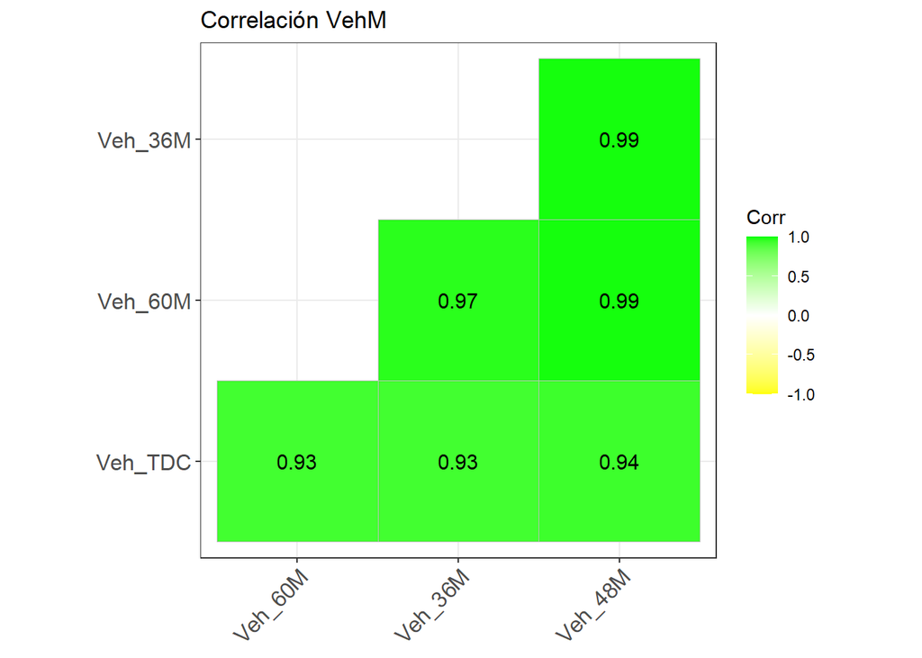

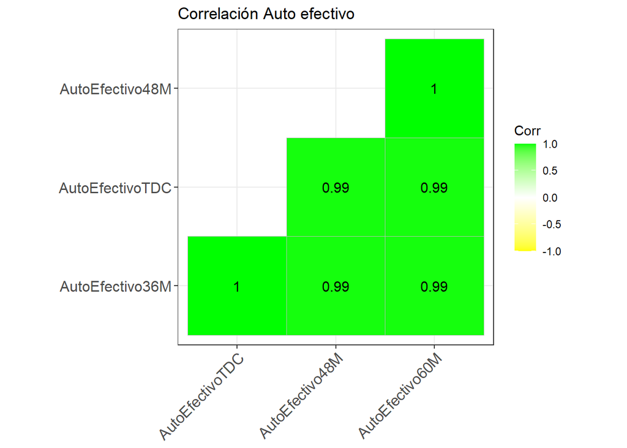

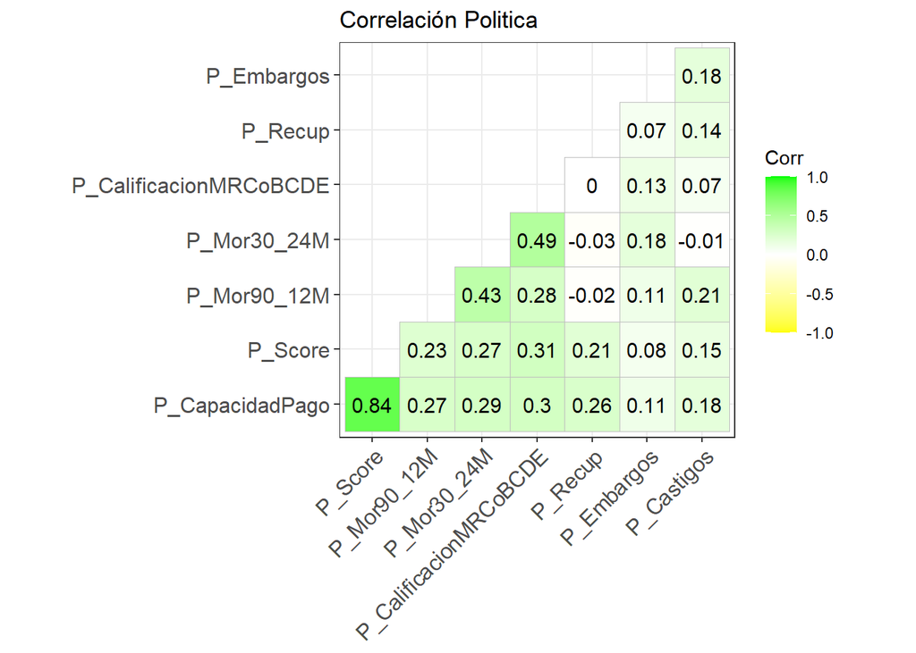

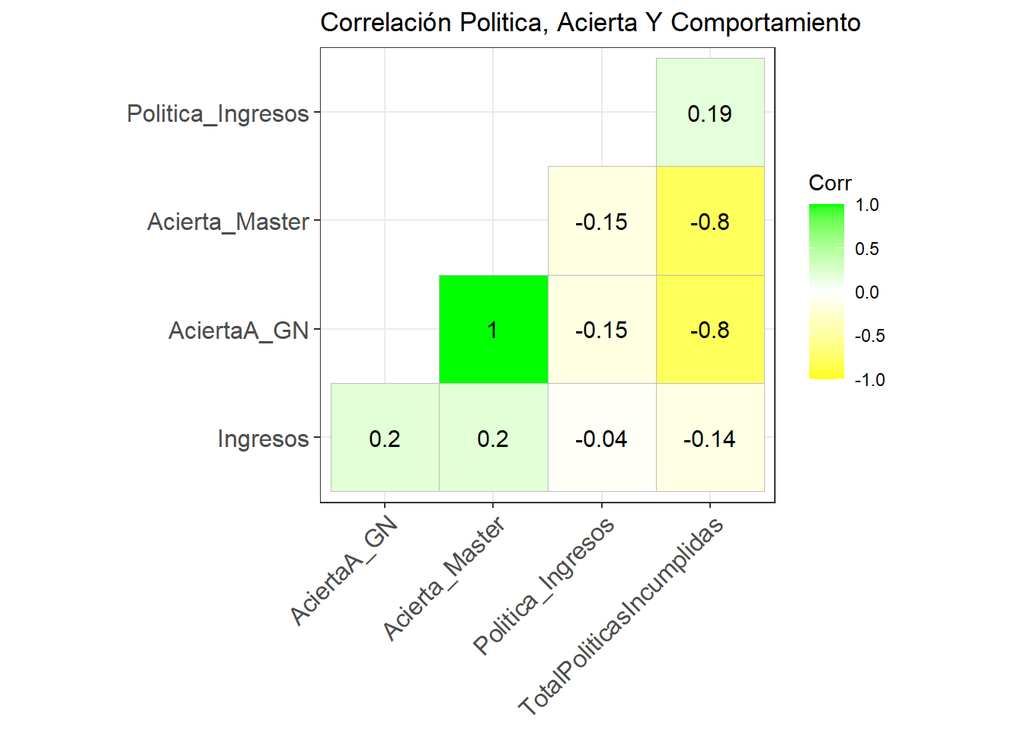

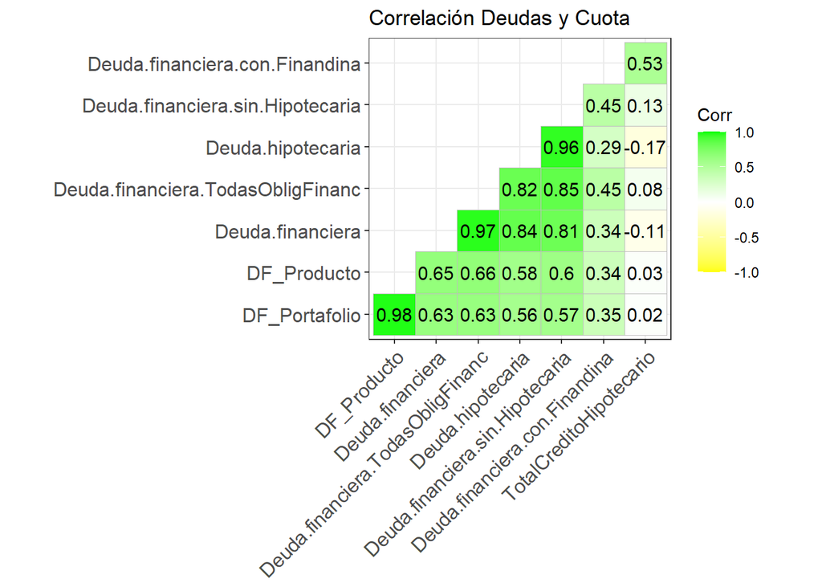

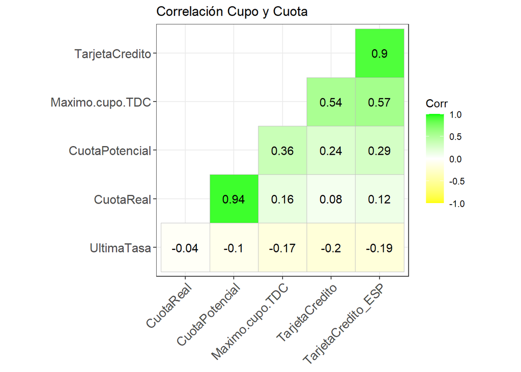

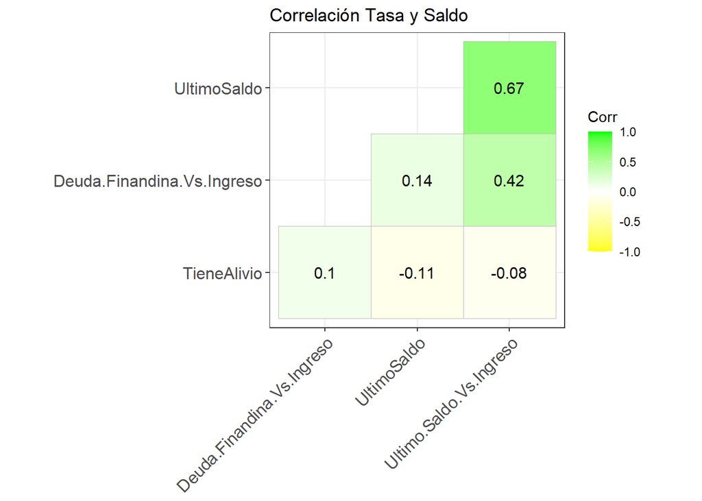

Existen variables que presentan alta correlacción, lo cual podría generar colinialidad, por esta razón se selecciona una variable que representara a otras u otras variables:

| Variable Seleccionada | Representa las Variables |
| --- | --- |
| Veh_48M | Veh_36M, Veh_48M, Veh_60M, Veh_TDC. |
| AutoEfectivoTDC | AutoEfectivo36M, AutoEfectivo48M, AutoEfectivo60M |
| P_Score | P_CapacidadPago |
| P_Mor30_24M | P_Mor90_12M, P_CalificacionMRCoBCDE |
| Acierta_Master | AciertaA_GN |
| DF_Portafolio | DF_Producto |
| Deuda financiera | Deuda financiera-TodasObligFinanc |
| Deuda financiera sin Hipotecaria | Deuda hipotecaria |
| Deuda financiera con Finandina | TotalCreditoHipotecario |
| CuotaReal | CuotaPotencial |
| TarjetaCredito | TarjetaCredito_ESP, Maximo cupo TDC |

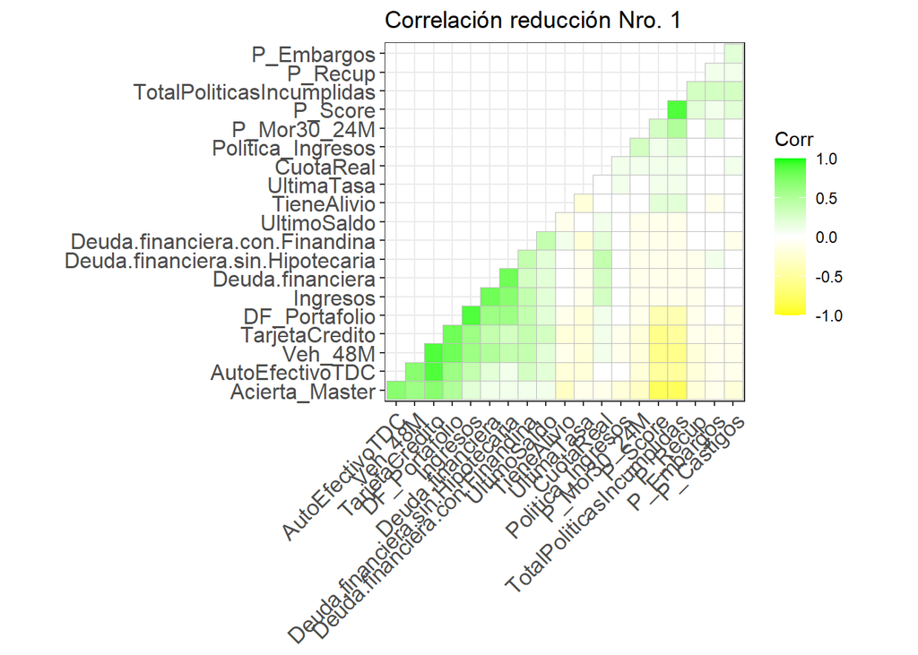

Existe un grupo de variables binarias, las cuales seran estudiadas para revisar la participación de cada marca y de esta manera decidir si se mantienen o excluyen:

```
## # A tibble: 2 x 3
##   P_Score Casos Parti
##     <dbl> <int> <dbl>
## 1       0   415 0.796
## 2       1   106 0.204
```

```
## [1] "La variable P_Score presenta participación en las dos categorias por encima de 2%, se mantendra dentro del estudio"
```

```
## # A tibble: 2 x 3
##   P_Mor30_24M Casos Parti
##         <dbl> <int> <dbl>
## 1           0   509 0.977
## 2           1    12 0.023
```

[output not shown]

```
## # A tibble: 2 x 3
##   P_Embargos Casos  Parti
##        <dbl> <int>  <dbl>
## 1          0   512 0.983
## 2          1     9 0.0173
```

```
## [1] "La variable P_Embargos presenta participación en las dos categorias por debajo de 2%, se excluira dentro del estudio"
```

```
## # A tibble: 2 x 3
##   P_Recup Casos  Parti
##     <dbl> <int>  <dbl>
## 1       0   507 0.973
## 2       1    14 0.0269
```

[output not shown]

```
## # A tibble: 2 x 3
##   P_Castigos Casos   Parti
##        <dbl> <int>   <dbl>
## 1          0   518 0.994
## 2          1     3 0.00580
```

```
## [1] "La variable P_Castigos presenta participación en las dos categorias por debajo de 2%, se excluira dentro del estudio"
```

```
## # A tibble: 2 x 3
##   Politica_Ingresos Casos  Parti
##               <dbl> <int>  <dbl>
## 1                 0   520 0.998
## 2                 1     1 0.0019
```

```
## [1] "La variable Politica_Ingresos presenta participación en las dos categorias por debajo de 2%, se excluira dentro del estudio"
```

```
## 'data.frame':    521 obs. of  20 variables:
##  $ Veh_48M                         : num  1.83e+07 2.00e+07 4.89e+07 2.00e+07 2.00e+07 0.00 0.00 1.00e+08 1.00e+08 1.00e+08 ...
##  $ AutoEfectivoTDC                 : num  2.2e+06 1.0e+06 3.0e+06 1.0e+06 1.0e+06 0.0 0.0 4.0e+06 4.0e+06 1.4e+07 ...
##  $ P_Score                         : num  0 1 0 1 1 1 1 0 0 0 ...
##  $ P_Mor30_24M                     : num  0 0 0 0 0 0 1 0 0 0 ...
##  $ P_Embargos                      : num  0 0 0 0 0 0 1 0 0 0 ...
##  $ P_Recup                         : num  0 0 0 0 0 0 0 0 0 0 ...
##  $ P_Castigos                      : num  0 0 0 0 0 0 0 0 0 0 ...
##  $ Politica_Ingresos               : num  0 0 0 0 0 0 0 0 0 0 ...
##  $ TotalPoliticasIncumplidas       : num  0 1 1 1 2 2 6 0 0 0 ...
##  $ Acierta_Master                  : num  745 693 782 707 700 680 477 843 842 942 ...
##  $ DF_Portafolio                   : num  559500 1292500 1498750 1408750 2762750 ...
##  $ Deuda.financiera                : num  4.10e+07 2.38e+06 2.08e+07 1.01e+08 4.57e+07 ...
##  $ Deuda.financiera.con.Finandina  : num  40951000 12973000 16554000 31235000 11015000 ...
##  $ Deuda.financiera.sin.Hipotecaria: num  4.10e+07 1.54e+07 2.99e+07 1.01e+08 5.67e+07 ...
##  $ TarjetaCredito                  : num  2238000 1000000 5995000 1000000 1000000 ...
##  $ CuotaReal                       : num  1123588 1571267 4318791 2887972 8005563 ...
##  $ Ingresos                        : num  2238000 5170000 5995000 5635000 11051000 ...
##  $ UltimaTasa                      : num  0.125 0.223 0.15 0.194 0.164 ...
##  $ UltimoSaldo                     : num  10037902 10181430 3162681 26150639 2000000 ...
##  $ TieneAlivio                     : num  1 1 1 1 1 1 1 0 1 0 ...
```

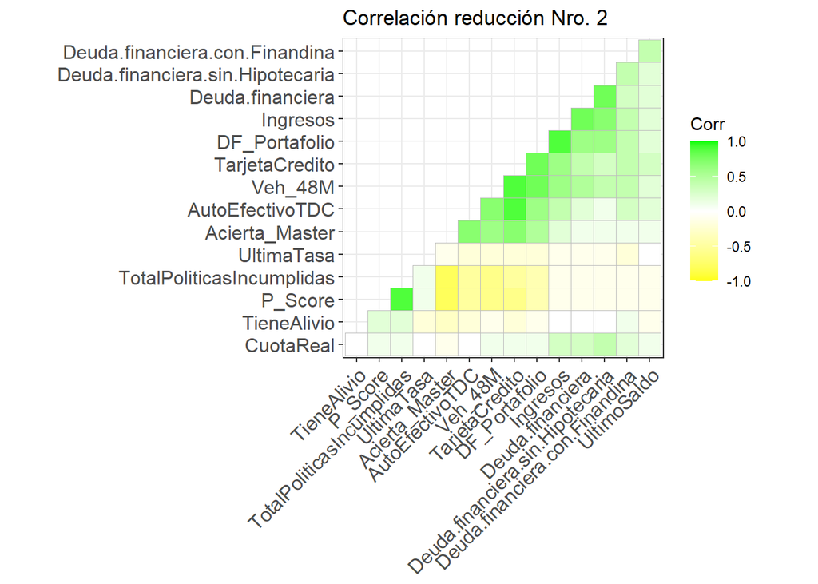

## 4. Normalización de variables Y Modelo No Supervisado

Se realiza una normalización de las variables númericas (diferente a las binarias) con el objetivo de eliminar el efecto de las distancias, dada la escala de cada una.

Normalización de las Variables –>> Var - Media(Var)/Desviación (Var)

Gráfica de la suma de cuadrados para identificar el número optimo de grupos:

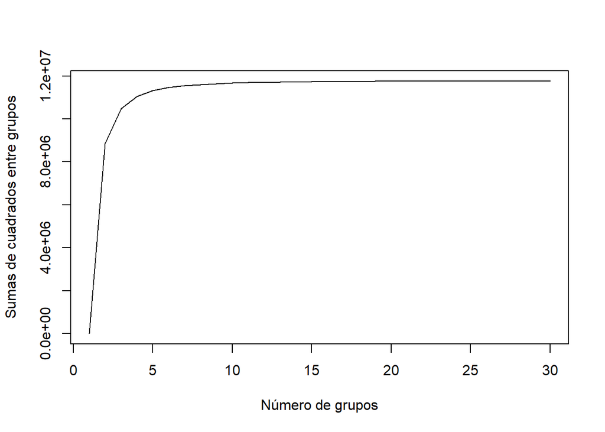

El resultado gráfico sugiere que el punto inflección en donde la curva disminuye la pendiente, se encuentra en los grupos 3 a 4, razón por la cual se define seleccionar 3 Cluster.

```
## 'data.frame':    521 obs. of  16 variables:
##  $ ID: num  11 12 13 14 15 16 17 18 19 20 ...
##  $ A : num  -0.8413 -0.7926 0.0346 -0.7926 -0.7926 ...
##  $ B : num  -0.569 -0.868 -0.37 -0.868 -0.868 ...
##  $ C : num  0 1 0 1 1 1 1 0 0 0 ...
##  $ D : num  0 1 1 1 2 2 6 0 0 0 ...
##  $ E : num  -0.499 -0.981 -0.155 -0.851 -0.916 ...
##  $ G : num  -0.587 -0.319 -0.244 -0.277 0.218 ...
##  $ H : num  -0.431 -0.612 -0.525 -0.149 -0.408 ...
##  $ I : num  0.2517 -0.72 -0.5957 -0.0858 -0.788 ...
##  $ J : num  -0.3966 -0.5597 -0.4672 -0.0143 -0.2961 ...
##  $ K : num  -0.77 -0.978 -0.139 -0.978 -0.978 ...
##  $ L : num  -0.3442 -0.3033 -0.0523 -0.183 0.2846 ...
##  $ M : num  -0.745 -0.404 -0.308 -0.35 0.279 ...
##  $ N : num  -0.2248 0.9974 0.0898 0.6402 0.2589 ...
##  $ O : num  -0.0418 -0.0331 -0.4574 0.9321 -0.5277 ...
##  $ P : Factor w/ 2 levels "0","1": 2 2 2 2 2 2 2 1 2 1 ...
```

```
## K-means clustering with 3 clusters of sizes 286, 106, 129
##
## Cluster means:
##            A          B C          D          E          G          H
## 1 -0.1588689 -0.1145666 0 0.05944056  0.2815681 -0.2545113 -0.3214308
## 2 -1.2256377 -1.0555275 1 2.32075472 -1.5713551 -0.8299327 -0.1773624
## 3  1.3593341  1.1213331 0 0.05426357  0.6669392  1.2462255  0.8583692
##            I          J          K          L          M          N          O
## 1 -0.3014502 -0.2944251 -0.2077821 -0.2209693 -0.3979094  0.1118853 -0.1911754
## 2 -0.2009385 -0.1459797 -1.1052053  0.1982873 -0.2899399  0.1568707 -0.1393805
## 3  0.8334437  0.7727086  1.3688173  0.3269671  1.1204320 -0.3769572  0.5383760
##           P
## 1 0.4650350
## 2 0.7358491
## 3 0.4728682
##
## Clustering vector:
##   [1] 1 2 1 2 2 2 2 3 3 3 1 3 1 1 1 2 1 1 1 1 2 2 3 3 2 1 1 1 1 1 1 3 1 1 1 1 1
##  [38] 1 1 3 1 3 3 3 1 1 1 2 1 1 2 1 1 3 3 1 1 3 1 3 3 2 1 1 1 1 1 1 1 1 1 2 2 1
##  [75] 2 1 1 1 1 2 3 2 2 2 2 3 2 2 2 2 3 3 1 1 2 1 1 1 1 2 3 2 1 1 3 1 1 2 2 2 1
## [112] 3 2 2 1 1 2 1 2 3 2 2 3 2 1 1 1 2 1 2 1 1 1 1 1 1 2 1 1 2 1 1 1 1 1 3 1 1
## [149] 1 1 1 1 1 1 1 3 2 1 1 1 1 1 1 1 1 1 2 3 1 1 1 1 1 1 2 3 2 3 1 3 3 1 1 2 2
## [186] 1 3 3 3 3 1 1 1 2 2 1 1 3 1 2 3 2 3 2 1 3 3 1 1 1 1 2 1 1 1 3 1 2 1 1 3 1
## [223] 1 1 2 1 1 1 1 2 1 1 1 1 3 1 1 1 3 2 3 2 1 1 3 1 1 1 1 3 1 1 1 2 1 1 1 3 2
## [260] 2 1 3 1 3 2 1 3 1 3 3 2 3 1 3 1 1 3 1 1 1 3 1 1 3 1 2 1 3 1 3 1 2 1 1 2 3
## [297] 3 3 1 3 1 3 1 2 3 1 2 1 1 3 1 1 2 2 1 2 1 1 3 1 3 2 1 1 2 2 1 1 1 3 2 2 1
## [334] 2 1 1 2 2 1 1 1 2 2 3 2 3 1 3 3 2 2 1 1 1 3 1 3 3 1 1 1 1 2 3 3 1 1 1 1 2
## [371] 3 3 1 1 1 3 1 3 3 1 1 2 3 1 2 3 3 1 1 3 2 2 1 1 2 3 1 1 1 1 2 3 1 3 1 3 1
## [408] 1 2 1 1 1 3 1 1 3 1 1 1 1 3 1 1 1 2 3 3 1 3 1 1 3 3 3 1 2 1 3 3 3 1 3 2 1
## [445] 1 2 3 3 1 3 3 1 1 1 1 1 3 3 3 3 2 3 2 3 2 3 1 1 1 3 3 1 3 1 1 1 3 3 3 1 1
## [482] 1 1 1 1 1 1 1 1 2 1 1 3 1 1 3 1 2 1 1 1 1 1 1 3 3 1 1 2 1 1 3 3 1 2 2 2 1
## [519] 1 1 1
##
## Within cluster sum of squares by cluster:
## [1] 1052.228 1038.150 2044.805
##  (between_SS / total_SS =  41.2 %)
##
## Available components:
##
## [1] "cluster"      "centers"      "totss"        "withinss"     "tot.withinss"
## [6] "betweenss"    "size"         "iter"         "ifault"
```

```
## grupos
##   1   2   3
## 286 106 129
```

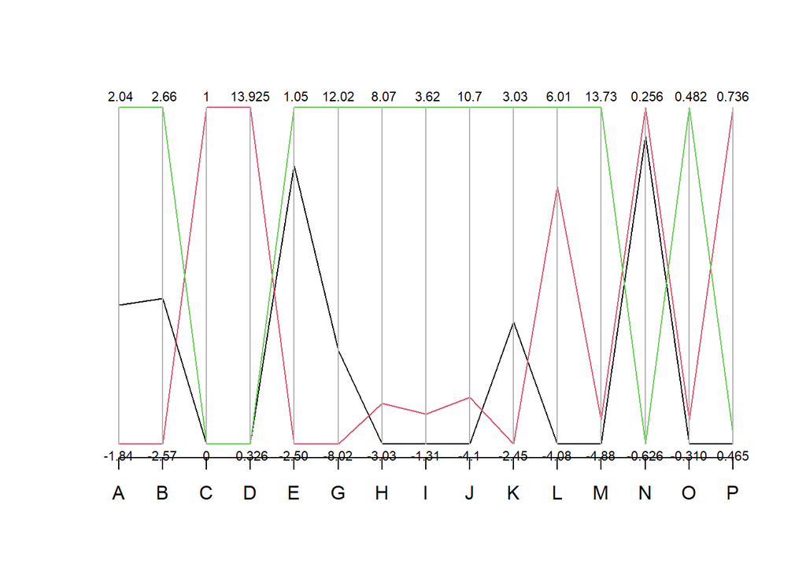

| A = Veh_48M | B = AutoEfectivoTDC | C = P_Score | D = TotalPoliticasIncumplidas |
| --- | --- | --- | --- |
| E = Acierta_Master | G = DF_Portafolio | H = Deuda.financiera | I = Deuda.financiera.con.Finandina |
| J = Deuda.financiera.sin.Hipotecaria | K = TarjetaCredito | L = CuotaReal | M = Ingresos |
| N = UltimaTasa | O = UltimoSaldo | P = TieneAlivio |  |

## 5. Modelo Supervisado KNN

Con este modelo se busca establecer la capacidad predictora de las variables seleccionadas para identificar los clientes que presentan alivios.

Se definen los conjuntos de entrenamiento y validación

```r
set.seed(190221)
indices_entrenamiento = sample(1:nrow(clus), 0.7 * nrow(clus))
indices_prueba = setdiff(1:nrow(clus), indices_entrenamiento)

# Utilizando los índices se conforman los conjuntos de datos.
datos_entrenamiento = clus[indices_entrenamiento,]
datos_prueba = clus[indices_prueba,]
```

Selección de Variables dependientes y variable objetivo

```r
# La función toma por aparte las características (X) y las clases (Y)
train = datos_entrenamiento[, -15]
train_lab = datos_entrenamiento[, "P"] #Y

test = datos_prueba[, -15]
test_lab = datos_prueba[, "P"]
```

Selección de del punto óptimo de vecinos con menor error de clasificación

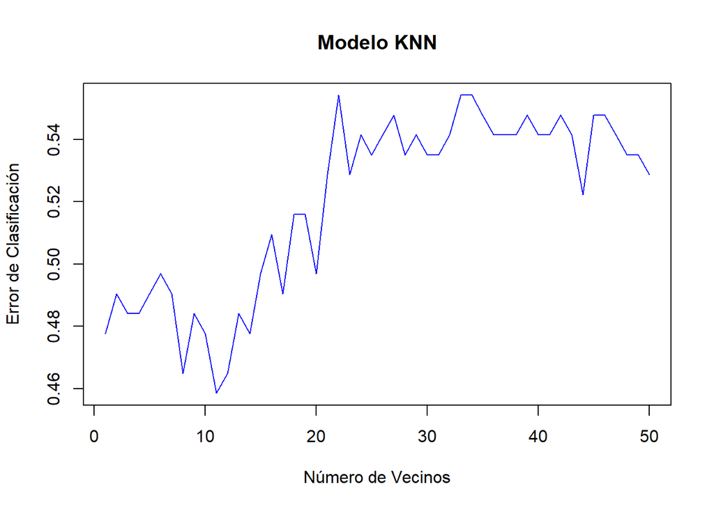

```r
#librería para utilizar KNN
library("class")

set.seed(190221)
max_k = 50
error = matrix(,max_k, 2)

for (K in 1:max_k){
  preds = knn(train = train, test = test, cl=train_lab, k = K)
  error[K, 1] = K
  error[K, 2] = 1 - mean(preds == test_lab)
}

plot(error, type = "l", xlab = "Número de Vecinos", ylab = "Error de Clasificación",
     main = "Modelo KNN", col = "blue")
```

Se observa que el punto con menor error de clasificación se encuentra en 11

Prediciones y precisión del modelo

```r
# Arroja la predicción para los datos de test
set.seed(190221)
preds = knn(train = train, test = test, cl=train_lab, k =11)

# Si se tabula la predicción (preds) con las clases originales se tiene...
matriz_confusion = function(Real, Predicted){
  conf = table(Real, Predicted)
  accuracy = mean(ifelse(Predicted == Real, 1, 0))
  return(list("ConfusionMatrix"= conf, "Accuracy" = accuracy))
}

matriz_confusion(test_lab, preds)
```

```
## $ConfusionMatrix
##     Predicted
## Real  0  1
##    0 33 55
##    1 17 52
##
## $Accuracy
## [1] 0.5414013
```

```r
VP <- 52; VN <-33; FN <-17; FP <-55; Tot <- 157
Sensibilidad = VP / (VP + FN) #% de Casos realmente con Alivio
Especificidad = VN / (VN + FP) #% de Casos realmente sin Alivio
Precision = VP / (VP + FP)
Exactitud = (VP + VN) / Tot
print(cat(c("Sensibilidad = ", Sensibilidad)))
```

```
## Sensibilidad =  0.753623188405797NULL
```

```r
print(cat(c("Especificidad = ", Especificidad)))
```

```
## Especificidad =  0.375NULL
```

```r
print(cat(c("Precisión = ", Precision)))
```

```
## Precisión =  0.485981308411215NULL
```

### Conclusión Modelo de Segmentación (KNN)

Los resultados del modelo no son los esperados, una exactitud de 54% es un valor muy bajo para selecionar un modelo de predicción, además, se observa un valor alto en los falsos positivos y falsos negativos.

## 6. Gobierno de Datos

El gobierno de datos integra todas las políticas y procedimientos que permiten administrar y gestionar de forma adecuada uno de los activos más importantes para las organizaciones, la información. Dentro de los pilares principales se encuentran la relevancia, aprovechamiento, integridad y seguridad de los mismos.

En este caso de estudio se observa que la gran mayoria de los datos tienen alta sensibilidad, en primera instancia se encuentran expuestos los datos personales del cliente (ID, ubicación y contactabilida), como también la información finaciera, lo cual esta bien para el uso interno y su disponibilidad no puede ser abierta a todos los miembros de la organización, de hecho, se deben generar roles de administración, backup y gestión de la demanda de datos que respondan a las necesidades de cada área.

Una metodología de alto impacto para el aseguramiento de la información, en lo que consierne a datos sensibles, es la anonimización de la información, la cual puede tener una tabla relacional con acceso restringido.